# ML1 Classification - Travel Insurance Prediction

Edyta Pszczółkowska

2 08 2021

The presented project is a classification model based on a dataset taken from kaggle:

https://www.kaggle.com/tejashvi14/travel-insurance-prediction-data

I will try to predict whether a given customer may potentially buy a additional travel insurance. Such a model is a great example how machine learning algorithms and modern statistical packages may support business.

After brief variables review and their transformations I will implement 3 different algorithms: logistic regression, k-nearest neighbors and SVM using 2 different kernel functions - polynomial and radial (gaussian).

###Loading data and necessary packages:

###Variables review and their transformation

Let’s check the structure of the dataset:

```r
glimpse(data)
```

```
## Rows: 1,987
## Columns: 10
## $ X                   <int> 0, 1, 2, 3, 4, 5, 6, 7, 8, 9, 10, 11, 12, 13, 1...
## $ Age                 <int> 31, 31, 34, 28, 28, 25, 31, 31, 28, 33, 31, 26,...
## $ Employment.Type     <chr> "Government Sector", "Private Sector/Self Emplo...
## $ GraduateOrNot       <chr> "Yes", "Yes", "Yes", "Yes", "Yes", "No", "Yes",...
## $ AnnualIncome        <int> 400000, 1250000, 500000, 700000, 700000, 115000...
## $ FamilyMembers       <int> 6, 7, 4, 3, 8, 4, 4, 3, 6, 3, 9, 5, 6, 6, 3, 7,...
## $ ChronicDiseases     <int> 1, 0, 1, 1, 1, 0, 0, 0, 1, 0, 1, 0, 0, 0, 0, 0,...
## $ FrequentFlyer       <chr> "No", "No", "No", "No", "Yes", "No", "No", "Yes...
## $ EverTravelledAbroad <chr> "No", "No", "No", "No", "No", "No", "No", "Yes"...
## $ TravelInsurance     <int> 0, 0, 1, 0, 0, 0, 0, 1, 1, 0, 0, 1, 1, 1, 0, 0,...
```

Whereas almost all variable names are rather self- explanatory, let’s take a look at “Employment type”:

```r
table(data$Employment.Type)
```

```
##
##            Government Sector Private Sector/Self Employed
##                          570                         1417
```

Let’s recode this variable and all other binary variables to 0/1 notation and make them factors:

```r
data$Employment.Type <-  as.factor(ifelse(data$Employment.Type == "Private Sector/Self Employed", 0 , 1))
data$GraduateOrNot <- as.factor(ifelse(data$GraduateOrNot == "No", 0 , 1))
data$FrequentFlyer <- as.factor(ifelse(data$FrequentFlyer == "No", 0 , 1))
data$EverTravelledAbroad <- as.factor(ifelse(data$EverTravelledAbroad == "No", 0 , 1))
data$ChronicDiseases <- as.factor(data$ChronicDiseases)
data$TravelInsurance <- as.factor(data$TravelInsurance)


summary(data)
```

```
##        X               Age        Employment.Type GraduateOrNot
##  Min.   :   0.0   Min.   :25.00   0:1417          0: 295
##  1st Qu.: 496.5   1st Qu.:28.00   1: 570          1:1692
##  Median : 993.0   Median :29.00
##  Mean   : 993.0   Mean   :29.65
##  3rd Qu.:1489.5   3rd Qu.:32.00
##  Max.   :1986.0   Max.   :35.00
##   AnnualIncome     FamilyMembers   ChronicDiseases FrequentFlyer
##  Min.   : 300000   Min.   :2.000   0:1435          0:1570
##  1st Qu.: 600000   1st Qu.:4.000   1: 552          1: 417
##  Median : 900000   Median :5.000
##  Mean   : 932763   Mean   :4.753
##  3rd Qu.:1250000   3rd Qu.:6.000
##  Max.   :1800000   Max.   :9.000
##  EverTravelledAbroad TravelInsurance
##  0:1607              0:1277
##  1: 380              1: 710
##
##
##
##
```

Let’s count missings in every column:

```r
colSums(is.na(data))
```

```
##                   X                 Age     Employment.Type       GraduateOrNot
##                   0                   0                   0                   0
##        AnnualIncome       FamilyMembers     ChronicDiseases       FrequentFlyer
##                   0                   0                   0                   0
## EverTravelledAbroad     TravelInsurance
##                   0                   0
```

No NAs in this dataset, great.

Let’s see the distribution of “age” variable….

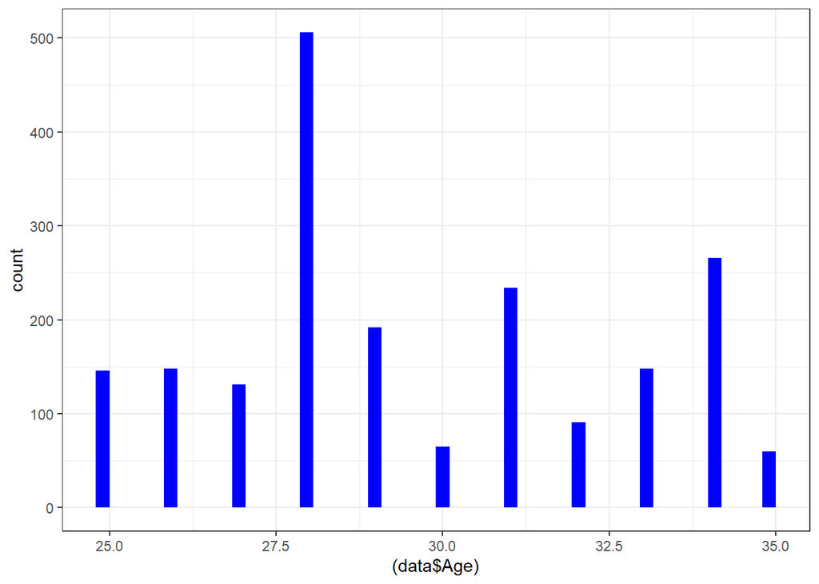

```r
ggplot(data,
       aes(x = (data$Age))) +
  geom_histogram(fill = "blue",
                 bins = 50) +
  theme_bw()
```

….and “AnnualIncome” (normal and logarithm form)

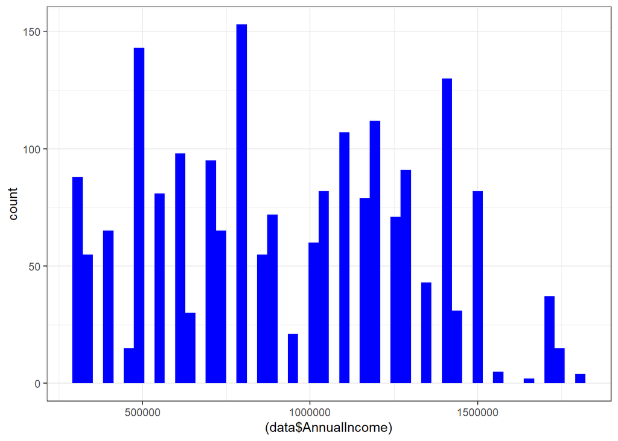

```r
ggplot(data,
       aes(x = (data$AnnualIncome))) +
  geom_histogram(fill = "blue",
                 bins = 50) +
  theme_bw()
```

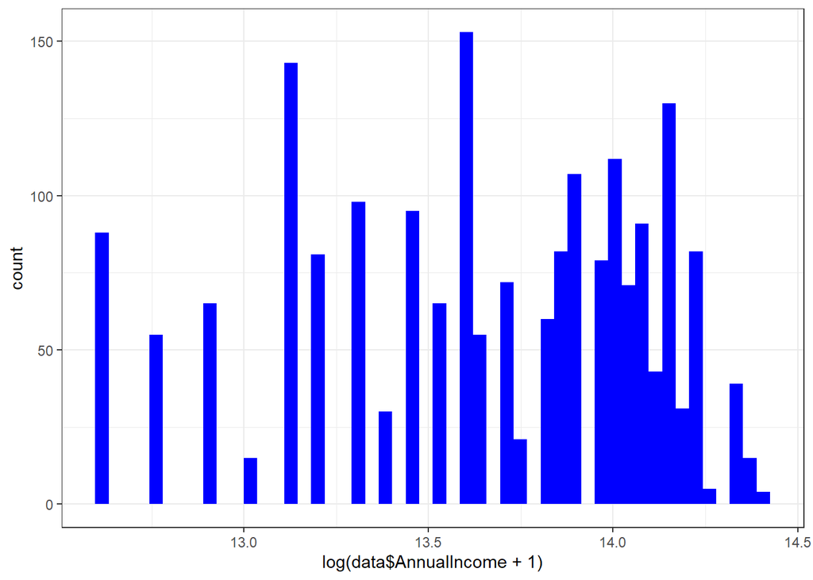

```r
ggplot(data,
       aes(x = log(data$AnnualIncome+1))) +
  geom_histogram(fill = "blue",
                 bins = 50) +
  theme_bw()
```

As the logarithm form isn’t symmetric as well I will stick to normal form.

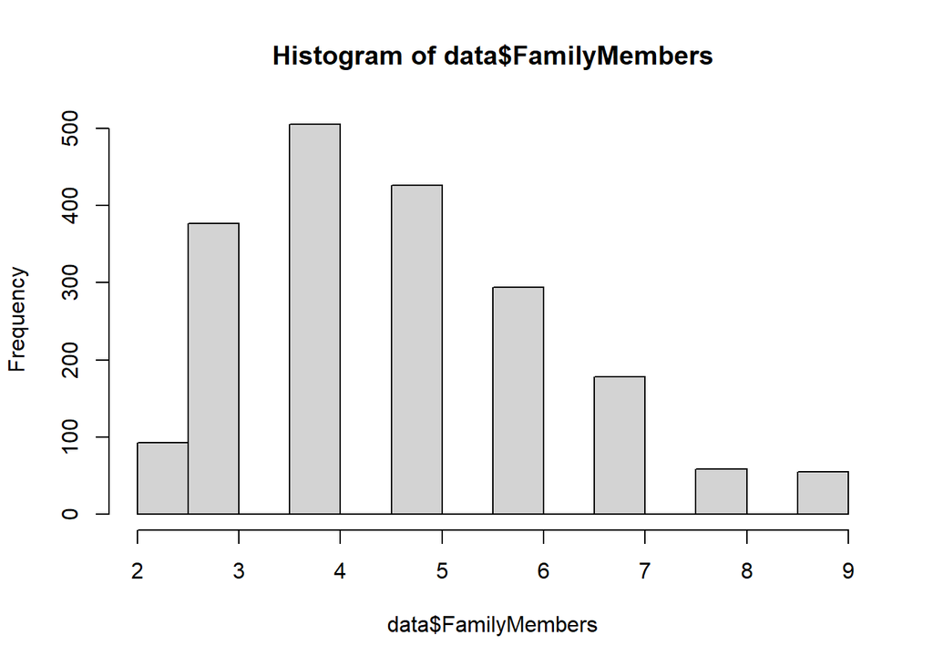

```r
hist(data$FamilyMembers)
```

Let’s check the correlations Firstly for numeric variables…:

```r
cor(data[,c("Age", "AnnualIncome", "FamilyMembers")],
      use = "pairwise.complete.obs")
```

```
##                       Age AnnualIncome FamilyMembers
## Age            1.00000000  -0.02010149    0.02740866
## AnnualIncome  -0.02010149   1.00000000   -0.01536739
## FamilyMembers  0.02740866  -0.01536739    1.00000000
```

We don’t see any significant collinearity between numerical variables.

Let’s see the relationship between the dependent variable and all binary variables:

```r
DescTools::CramerV(data$Employment.Type,
                   data$TravelInsurance)
```

```
## [1] 0.1478469
```

```r
DescTools::CramerV(data$GraduateOrNot,
                   data$TravelInsurance)
```

```
## [1] 0.01893352
```

```r
DescTools::CramerV(data$ChronicDiseases,
                   data$TravelInsurance)
```

```
## [1] 0.01818961
```

```r
DescTools::CramerV(data$FrequentFlyer,
                   data$TravelInsurance)
```

```
## [1] 0.2321031
```

```r
DescTools::CramerV(data$EverTravelledAbroad,
                   data$TravelInsurance)
```

```
## [1] 0.4331826
```

```r
options(contrasts = c("contr.treatment",
                      "contr.treatment"))


set.seed(12345)
insurance_which_train <- createDataPartition(data$TravelInsurance,
                                          p = 0.7,
                                          list = FALSE)



insurance_train <- data[insurance_which_train,]
insurance_test <- data[-insurance_which_train,]



table(insurance_train$TravelInsurance)
```

```
##
##   0   1
## 894 497
```

```r
table(insurance_test$TravelInsurance)
```

```
##
##   0   1
## 383 213
```

###Models

##Logistic regression

For all the models I will use the “train” function from the caret package. I will implement repeated cross validation method with 5 folds and 3 repeats.

Let’s play a game…

```r
ctrl_cv5x3a <- trainControl(method = "repeatedcv",
                            number = 5,
                            repeats = 3)

model_logistic <-
  train(TravelInsurance ~ .,
        data = insurance_train %>%
          dplyr::select(-X),
        method = "glm",
        family = "binomial",
        trControl = ctrl_cv5x3a)


summary(model_logistic)
```

```
##
## Call:
## NULL
##
## Deviance Residuals:
##     Min       1Q   Median       3Q      Max
## -2.2835  -0.8067  -0.5405   0.7003   2.2710
##
## Coefficients:
##                        Estimate Std. Error z value Pr(>|z|)
## (Intercept)          -5.601e+00  7.649e-01  -7.322 2.45e-13 ***
## Age                   7.552e-02  2.242e-02   3.369 0.000755 ***
## Employment.Type1     -1.541e-01  1.575e-01  -0.978 0.327983
## GraduateOrNot1        1.380e-01  1.999e-01   0.691 0.489840
## AnnualIncome          1.631e-06  2.166e-07   7.532 5.01e-14 ***
## FamilyMembers         1.311e-01  4.046e-02   3.239 0.001198 **
## ChronicDiseases1      1.211e-01  1.466e-01   0.826 0.408752
## FrequentFlyer1        4.995e-01  1.653e-01   3.022 0.002515 **
## EverTravelledAbroad1  1.703e+00  1.853e-01   9.189  < 2e-16 ***
## ---
## Signif. codes:  0 '***' 0.001 '**' 0.01 '*' 0.05 '.' 0.1 ' ' 1
##
## (Dispersion parameter for binomial family taken to be 1)
##
##     Null deviance: 1813.4  on 1390  degrees of freedom
## Residual deviance: 1430.4  on 1382  degrees of freedom
## AIC: 1448.4
##
## Number of Fisher Scoring iterations: 4
```

```r
model_logistic
```

```
## Generalized Linear Model
##
## 1391 samples
##    8 predictor
##    2 classes: '0', '1'
##
## No pre-processing
## Resampling: Cross-Validated (5 fold, repeated 3 times)
## Summary of sample sizes: 1113, 1114, 1112, 1113, 1112, 1113, ...
## Resampling results:
##
##   Accuracy   Kappa
##   0.7718622  0.4586237
```

We may see the variables “Employment type”, “Graduate or not” and “Chronic diseases” are not significant. As the p-values standing next to their coefficients are so high, I will exclude those variables from further analysis and re-estimate the logistic regression model:

```r
ctrl_cv5x3a <- trainControl(method = "repeatedcv",
                            number = 5,
                            repeats = 3)

model_logistic2 <-
  train(TravelInsurance ~ .,
        data = insurance_train %>%
          dplyr::select(-X, - GraduateOrNot, -ChronicDiseases, -Employment.Type ),
        method = "glm",
        family = "binomial",
        trControl = ctrl_cv5x3a)


summary(model_logistic2)
```

```
##
## Call:
## NULL
##
## Deviance Residuals:
##     Min       1Q   Median       3Q      Max
## -2.2481  -0.8057  -0.5429   0.7044   2.2824
##
## Coefficients:
##                        Estimate Std. Error z value Pr(>|z|)
## (Intercept)          -5.474e+00  7.464e-01  -7.333 2.25e-13 ***
## Age                   7.286e-02  2.223e-02   3.278 0.001045 **
## AnnualIncome          1.690e-06  2.082e-07   8.117 4.77e-16 ***
## FamilyMembers         1.330e-01  4.040e-02   3.293 0.000991 ***
## FrequentFlyer1        4.816e-01  1.642e-01   2.933 0.003361 **
## EverTravelledAbroad1  1.712e+00  1.850e-01   9.253  < 2e-16 ***
## ---
## Signif. codes:  0 '***' 0.001 '**' 0.01 '*' 0.05 '.' 0.1 ' ' 1
##
## (Dispersion parameter for binomial family taken to be 1)
##
##     Null deviance: 1813.4  on 1390  degrees of freedom
## Residual deviance: 1432.3  on 1385  degrees of freedom
## AIC: 1444.3
##
## Number of Fisher Scoring iterations: 4
```

```r
model_logistic2
```

```
## Generalized Linear Model
##
## 1391 samples
##    5 predictor
##    2 classes: '0', '1'
##
## No pre-processing
## Resampling: Cross-Validated (5 fold, repeated 3 times)
## Summary of sample sizes: 1113, 1112, 1112, 1114, 1113, 1113, ...
## Resampling results:
##
##   Accuracy   Kappa
##   0.7778668  0.4735999
```

Slightly better accuracy.

##K-nearest neighbours

For this part it is crucial to estimate the parameter k. For smaller samples it is advised to take as this value a square root of number of observations. For now, let’s plot the accuracy for k from 1 to 40 and use method “range” to scale the data:

```r
different_k <- data.frame(k = seq(1, 40, 2))



ctrl_cv5x3 <- trainControl(method = "repeatedcv",
                            number = 5,
                            repeats = 3)




model_knn <-
  train(TravelInsurance ~ .,
        data = insurance_train %>%
          dplyr::select(-X, - GraduateOrNot, -ChronicDiseases, -Employment.Type ),
        method = "knn",
        preProcess = c("range"),
        trControl = ctrl_cv5x3,
        tuneGrid = different_k)



model_knn
```

```
## k-Nearest Neighbors
##
## 1391 samples
##    5 predictor
##    2 classes: '0', '1'
##
## Pre-processing: re-scaling to [0, 1] (5)
## Resampling: Cross-Validated (5 fold, repeated 3 times)
## Summary of sample sizes: 1114, 1113, 1112, 1112, 1113, 1112, ...
## Resampling results across tuning parameters:
##
##   k   Accuracy   Kappa
##    1  0.7622810  0.4759409
##    3  0.7824026  0.5102082
##    5  0.7994170  0.5389610
##    7  0.8058850  0.5496043
##    9  0.8101930  0.5574663
##   11  0.8070781  0.5512746
##   13  0.8073049  0.5511067
##   15  0.8089853  0.5543796
##   17  0.8113895  0.5608600
##   19  0.8097194  0.5566603
##   21  0.8075611  0.5518474
##   23  0.8090043  0.5556166
##   25  0.8061283  0.5491185
##   27  0.8051691  0.5470929
##   29  0.8025303  0.5413878
##   31  0.8027753  0.5422585
##   33  0.8020576  0.5411100
##   35  0.8015797  0.5396368
##   37  0.8015814  0.5396504
##   39  0.8011001  0.5381510
##
## Accuracy was used to select the optimal model using the largest value.
## The final value used for the model was k = 17.
```

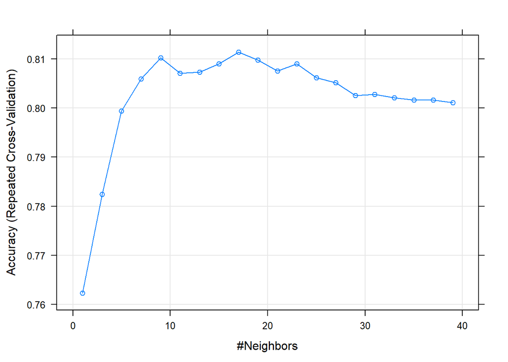

```r
plot(model_knn)
```

The highest accuracy was obtained for k=17. From k ~ 30 the accuracy is gradually becoming stable, so there is no need to check the model for the square root of number of observations (k~~ 44)

###SVM - polynomial

Let’s check which value of parameters are optimal:

```r
svm_parametersPoly <- expand.grid(C = c(0.001,  1),
                                  degree = 1:5,
                                  scale = 1)

svm_parametersPoly
```

```
##        C degree scale
## 1  0.001      1     1
## 2  1.000      1     1
## 3  0.001      2     1
## 4  1.000      2     1
## 5  0.001      3     1
## 6  1.000      3     1
## 7  0.001      4     1
## 8  1.000      4     1
## 9  0.001      5     1
## 10 1.000      5     1
```

```r
ctrl_cv5x3 <- trainControl(method = "repeatedcv",
                            number = 5,
                            repeats = 3)

model_SVM_poly <- train(TravelInsurance ~ .,
        data = insurance_train %>%
          dplyr::select(-X, - GraduateOrNot, -ChronicDiseases, -Employment.Type),
        method = "svmPoly",
        tuneGrid = svm_parametersPoly,
        trControl = ctrl_cv5x3)
```

###Support vector machine - radial

Here we also have to tune parameters, by trial and error I know that parameter C must be around 26:

```r
parametersC_sigma <-
  expand.grid(C = c(24, 25, 26, 27, 28),
              sigma = c(0.05, 0.1, 0.2, 0.5, 1))



model_SVM_radial <- train(TravelInsurance ~ .,
        data = insurance_train %>%
          dplyr::select(-X, - GraduateOrNot, -ChronicDiseases, -Employment.Type),
          method = "svmRadial",
          tuneGrid = parametersC_sigma,
          trControl = ctrl_cv5x3)



model_SVM_radial
```

```
## Support Vector Machines with Radial Basis Function Kernel
##
## 1391 samples
##    5 predictor
##    2 classes: '0', '1'
##
## No pre-processing
## Resampling: Cross-Validated (5 fold, repeated 3 times)
## Summary of sample sizes: 1113, 1113, 1114, 1112, 1112, 1113, ...
## Resampling results across tuning parameters:
##
##   C   sigma  Accuracy   Kappa
##   24  0.05   0.8226640  0.5814472
##   24  0.10   0.8236241  0.5857089
##   24  0.20   0.8231444  0.5851300
```

[output cut: 25 more lines]

### Models evaluation

To evaluate the models and compare the results on the test sample, I will use confusionMatrix function to obtain basic evaluation measures:

```r
model_logistic_forecasts <- predict(model_logistic2,
                                  insurance_test,
                                  type = "prob")



confusionMatrix(data = as.factor(ifelse(model_logistic_forecasts["1"] > 0.5,
                                        1,
                                        0)),
                  reference = insurance_test$TravelInsurance,
                positive = "1")
```

```
## Confusion Matrix and Statistics
##
##           Reference
## Prediction   0   1
##          0 352 112
##          1  31 101
##
##                Accuracy : 0.7601
##                  95% CI : (0.7237, 0.7938)
##     No Information Rate : 0.6426
##     P-Value [Acc > NIR] : 4.580e-10
##
##                   Kappa : 0.4295
##
##  Mcnemar's Test P-Value : 2.233e-11
##
##             Sensitivity : 0.4742
##             Specificity : 0.9191
##          Pos Pred Value : 0.7652
##          Neg Pred Value : 0.7586
##              Prevalence : 0.3574
##          Detection Rate : 0.1695
##    Detection Prevalence : 0.2215
##       Balanced Accuracy : 0.6966
##
##        'Positive' Class : 1
##
```

```r
model_knn_forecasts <- predict(model_knn,
                                  insurance_test,
                                  type = "prob")





confusionMatrix(data = as.factor(ifelse(model_knn_forecasts["1"] > 0.5,
                                        1,
                                        0)),
                  reference = insurance_test$TravelInsurance,
                positive = "1")
```

```
## Confusion Matrix and Statistics
##
##           Reference
## Prediction   0   1
##          0 360  89
##          1  23 124
##
##                Accuracy : 0.8121
##                  95% CI : (0.7784, 0.8427)
##     No Information Rate : 0.6426
##     P-Value [Acc > NIR] : < 2.2e-16
##
##                   Kappa : 0.5607
##
##  Mcnemar's Test P-Value : 8.153e-10
##
##             Sensitivity : 0.5822
##             Specificity : 0.9399
##          Pos Pred Value : 0.8435
##          Neg Pred Value : 0.8018
##              Prevalence : 0.3574
##          Detection Rate : 0.2081
##    Detection Prevalence : 0.2466
##       Balanced Accuracy : 0.7611
##
##        'Positive' Class : 1
##
```

```r
model_SVM_poly_forecasts <- predict(model_SVM_poly,
                                  insurance_test)



confusionMatrix(data = model_SVM_poly_forecasts,
                reference = insurance_test$TravelInsurance,
                positive = "1")
```

```
## Confusion Matrix and Statistics
##
##           Reference
## Prediction   0   1
##          0 364  93
##          1  19 120
##
##                Accuracy : 0.8121
##                  95% CI : (0.7784, 0.8427)
##     No Information Rate : 0.6426
##     P-Value [Acc > NIR] : < 2.2e-16
##
##                   Kappa : 0.5567
##
##  Mcnemar's Test P-Value : 5.279e-12
##
##             Sensitivity : 0.5634
##             Specificity : 0.9504
##          Pos Pred Value : 0.8633
##          Neg Pred Value : 0.7965
##              Prevalence : 0.3574
##          Detection Rate : 0.2013
##    Detection Prevalence : 0.2332
##       Balanced Accuracy : 0.7569
##
##        'Positive' Class : 1
##
```

```r
model_SVM_radial_forecasts <- predict(model_SVM_radial,
                                  insurance_test)




confusionMatrix(data = model_SVM_radial_forecasts,
                reference = insurance_test$TravelInsurance,
                positive = "1")
```

```
## Confusion Matrix and Statistics
##
##           Reference
## Prediction   0   1
##          0 365  93
##          1  18 120
##
##                Accuracy : 0.8138
##                  95% CI : (0.7801, 0.8442)
##     No Information Rate : 0.6426
##     P-Value [Acc > NIR] : < 2.2e-16
##
##                   Kappa : 0.5602
##
##  Mcnemar's Test P-Value : 2.16e-12
##
##             Sensitivity : 0.5634
##             Specificity : 0.9530
##          Pos Pred Value : 0.8696
##          Neg Pred Value : 0.7969
##              Prevalence : 0.3574
##          Detection Rate : 0.2013
##    Detection Prevalence : 0.2315
##       Balanced Accuracy : 0.7582
##
##        'Positive' Class : 1
##
```

###Refrences

1)Lab materials - R scripts and presentations

2)https://www.kaggle.com/tejashvi14/travel-insurance-prediction-data

3)https://www.rdocumentation.org/

4)https://stackoverflow.com/